# Market layout planning using clustering algorithms

Instacart is an American company founded in 2012 that operates a grocery delivery and pick-up service in the United States and Canada.

The company offers its services via a website and mobile app. The service allows customers to order groceries from participating retailers with the shopping being done by a personal shopper. Orders are fulfilled and delivered by a personal shopper, who picks, packs, and delivers the order.

Instamarket orders are available in [kaggle](https://www.kaggle.com/psparks/instacart-market-basket-analysis) and contain information about which items were present in each order, as well as the market layout: In which aisle the item was found and what department contains each aisle.

With this data, it is possible to analyze the relations between the orders to make business strategies regarding the layout of the hypermarket:

1. Which aisles should be grouped together in the same department?
2. Which departments should be close to one another?
3. For items that had no aisle assignment, to which aisle should they be sent?
4. Which items should be displayed near the cashier counters?

In the following analysis, all these questions will be explored.

```python
from math import trunc
import numpy as np
import pandas as pd
from sklearn.cluster import SpectralClustering,AgglomerativeClustering, AffinityPropagation, OPTICS
from scipy.sparse import csr, csr_matrix
from sklearn.decomposition import TruncatedSVD,SparsePCA
import matplotlib.pyplot as plt
from scipy.cluster.hierarchy import dendrogram, linkage
import matplotlib.gridspec as gridspec
import squarify
import itertools
import time
import pickle
import sys
import sys
from IPython.display import Markdown as md
pd.set_option('display.max_rows', 134)
```

```python
#Defining functions
def plot_dendrogram(model, **kwargs):
    '''
    Given a clustering model, plots a dendrogram.
    '''
    # Create linkage matrix and then plot the dendrogram

    # create the counts of samples under each node
    counts = np.zeros(model.children_.shape[0])
    n_samples = len(model.labels_)
    for i, merge in enumerate(model.children_):
        current_count = 0
        for child_idx in merge:
            if child_idx < n_samples:
                current_count += 1  # leaf node
            else:
                current_count += counts[child_idx - n_samples]
        counts[i] = current_count

    linkage_matrix = np.column_stack(
        [model.children_, model.distances_, counts]
    ).astype(float)

    # Plot the corresponding dendrogram
    dendrogram(linkage_matrix, **kwargs)

def cosine_similariy(v1,v2):
    '''
    Calculates cosine similarity between two arrays of values. (v1*v2)/(mod(v1)*mod(v2))

    vector1 - array with length N
    vector2 - array with length N

    '''
    mod1=np.sqrt((v1*v1).sum())
    mod2=np.sqrt((v2*v2).sum())
    dot_product=(v1*v2).sum()
    return dot_product/(mod1*mod2)
def invert_dictionary(dict_in):
    '''
    Inverts keys and values of dictionary
    '''
    return {v: k for k, v in dict_in.items()}
#Boolean variables to inform if there is a need to recalculate a section (or just import data that was calculated in this
#section previously so that there is no need to spend time recalculating)
recalculate_group_order_aisle=0
recalculate_cosine_similarity=0
recalculate_aisle_assignment=0
recalculate_group_order_department=0
recalculate_cosine_similarity_dept=0
recalculate_dept_product_dict=0
```

## 1. Data exploration

The data available in kaggle consists of:

1. A table that contains the order id and the product id
2. A table associating each product id to the product name and aisle id
3. A table associating each aisle id to the aisle name and department id
4. A table associating each department id to the department name.

By compiling all tables together, a compiled table is obtained. The table below shows a subsect of this table for order id number 10.

```python
#reading csvs
orders=pd.read_csv('../data/order_products__prior.csv')[['order_id','product_id']]

products=pd.read_csv('../data/products.csv')
aisles=pd.read_csv('../data/aisles.csv')
aisles_id=aisles['aisle_id']
departments=pd.read_csv('../data/departments.csv')

#getting unique aisles
unique_aisles_dep=products[['aisle_id','department_id']].drop_duplicates()
unique_aisles_dep=unique_aisles_dep.merge(aisles,on='aisle_id').merge(departments,on='department_id').sort_values(['department_id','aisle_id'])
#getting aisle and department relation
aisle_name_with_dep_id=unique_aisles_dep.sort_values(by='aisle_id')
aisle_name_with_dep_id=aisle_name_with_dep_id.apply(lambda x:x['aisle']+'('+str(x['department_id'])+')',axis=1)
unique_aisles_dep.reset_index(drop=True)

#dictionary with aisles and aisles id
aisles_dict=dict(zip(aisles['aisle_id'],aisles['aisle']))
departments_dict=dict(zip(unique_aisles_dep['department_id'],unique_aisles_dep['department']))
product_dict=dict(zip(products['product_name'],products['product_id']))
inverted_product_dict=invert_dictionary(product_dict)
aisle_dept_dict=dict(zip(unique_aisles_dep['aisle_id'],unique_aisles_dep['department_id']))

#merging orders, departments and aisles
complete_orders=orders.merge(products,on='product_id',how='left').merge(aisles,on='aisle_id').merge(departments,
                                                                                                    on='department_id')
#count number of items bought by aisle and calculate pctg
bought_by_aisle=complete_orders.groupby('aisle').count()[['order_id']].rename(columns={'order_id':'total_bought'}).sort_values(by='total_bought',ascending=False)
bought_by_aisle['%total']=bought_by_aisle['total_bought']/bought_by_aisle['total_bought'].sum()*100
bought_by_aisle['name']=bought_by_aisle.index
bought_by_aisle['name+pctg']=bought_by_aisle.apply(lambda x:x['name']+'\n'+'{:.1f}%'.format(x['%total']),axis=1)

#count number of items bought by department and calculate pctg
bought_by_department=complete_orders.groupby('department').count()[['order_id']].rename(columns={'order_id':'total_bought'}).sort_values(by='total_bought',ascending=False)
bought_by_department['%total']=bought_by_department['total_bought']/bought_by_department['total_bought'].sum()*100
bought_by_department['name']=bought_by_department.index
bought_by_department['name+pctg']=bought_by_department.apply(lambda x:x['name']+'\n'+'{:.1f}%'.format(x['%total']),axis=1)
```

```python
complete_orders[complete_orders['order_id']==10]
```

|  | order_id | product_id | product_name | aisle_id | department_id | aisle | department |
| --- | --- | --- | --- | --- | --- | --- | --- |
| 4413508 | 10 | 49235 | Organic Half & Half | 53 | 16 | cream | dairy eggs |
| 5414022 | 10 | 4796 | Baby Portabella Mushrooms | 83 | 4 | fresh vegetables | produce |
| 5414023 | 10 | 4605 | Yellow Onions | 83 | 4 | fresh vegetables | produce |
| 5414024 | 10 | 14992 | Green Beans | 83 | 4 | fresh vegetables | produce |
| 5414025 | 10 | 3464 | Organic Butterhead (Boston, Butter, Bibb) Lettuce | 83 | 4 | fresh vegetables | produce |
| 5414026 | 10 | 25720 | Organic Sunchoke | 83 | 4 | fresh vegetables | produce |
| 10597354 | 10 | 24852 | Banana | 24 | 4 | fresh fruits | produce |
| 10597355 | 10 | 47766 | Organic Avocado | 24 | 4 | fresh fruits | produce |
| 10597356 | 10 | 21137 | Organic Strawberries | 24 | 4 | fresh fruits | produce |
| 14515566 | 10 | 31717 | Organic Cilantro | 16 | 4 | fresh herbs | produce |
| 14515567 | 10 | 1529 | Parsley, Italian (Flat), New England Grown | 16 | 4 | fresh herbs | produce |
| 17016835 | 10 | 26842 | Boneless Beef Sirloin Steak | 122 | 12 | meat counter | meat seafood |
| 30638397 | 10 | 27156 | Organic Black Beans | 59 | 15 | canned meals beans | canned goods |
| 31619258 | 10 | 22122 | Stage 2 Green Bean Pear Greek Yogurt Baby Food | 92 | 18 | baby food formula | babies |
| 31619259 | 10 | 34134 | Spinach Peas & Pear Stage 2 Baby Food | 92 | 18 | baby food formula | babies |

```python
n_orders=len(pd.unique(complete_orders['order_id']))
n_products=len(pd.unique(complete_orders['product_id']))
n_aisles=len(pd.unique(complete_orders['aisle_id']))
n_depts=len(pd.unique(complete_orders['department_id']))
#md('From the data, there was a total of  **{}** unique orders, which contained **{}** unique different products. Each product was assigned to a specific aisle out of the **{}** possible values. Each aisle belonged to one of the **{}** total existing departments.'
#   .format(n_orders,n_products,n_aisles,n_depts))
```

From the data, there was a total of **3214874** unique orders, which contained **49677** unique different products. Each product was assigned to a specific aisle out of the **134** possible values. Each aisle belonged to one of the **21** total existing departments.

All aisles names and departments are shown in the table below.

Particular attention must be paid to aisle 100 (which was assigned to department 21), that is used for products missing the aisle assignment information, as well as aisle 6 (department 2), which in turn is used for products that had not a specific aisle. These two classes will later be assigned to the other 132 aisles by using clustering analysis.

```python
unique_aisles_dep.set_index('aisle_id')
```

| aisle_id | department_id | aisle | department |
| --- | --- | --- | --- |
| 34 | 1 | frozen meat seafood | frozen |
| 37 | 1 | ice cream ice | frozen |
| 38 | 1 | frozen meals | frozen |
| 42 | 1 | frozen vegan vegetarian | frozen |
| 52 | 1 | frozen breakfast | frozen |
| 58 | 1 | frozen breads doughs | frozen |
| 79 | 1 | frozen pizza | frozen |
| 113 | 1 | frozen juice | frozen |
| 116 | 1 | frozen produce | frozen |
| 119 | 1 | frozen dessert | frozen |
| 129 | 1 | frozen appetizers sides | frozen |
| 6 | 2 | other | other |
| 8 | 3 | bakery desserts | bakery |
| 43 | 3 | buns rolls | bakery |
| 93 | 3 | breakfast bakery | bakery |
| 112 | 3 | bread | bakery |
| 128 | 3 | tortillas flat bread | bakery |
| 16 | 4 | fresh herbs | produce |
| 24 | 4 | fresh fruits | produce |
| 32 | 4 | packaged produce | produce |
| 83 | 4 | fresh vegetables | produce |
| 123 | 4 | packaged vegetables fruits | produce |
| 27 | 5 | beers coolers | alcohol |
| 28 | 5 | red wines | alcohol |
| 62 | 5 | white wines | alcohol |
| 124 | 5 | spirits | alcohol |
| 134 | 5 | specialty wines champagnes | alcohol |
| 30 | 6 | latino foods | international |
| 33 | 6 | kosher foods | international |
| 66 | 6 | asian foods | international |

[output cut: 104 more lines]

By counting the percentage of items belonging to each department, it is possible to understand which departments represented most of the products sold. Produce contained 29.2% of items sold, followed by dairy eggs (16.7%) and snacks (8.9%).

When looking on a division by aisles, the most important was fresh fruits (11.2%), followed by fresh vegetables (10.5%) and packaged vegetable fruits (5.4%)

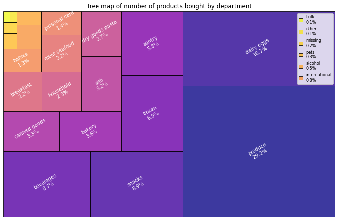

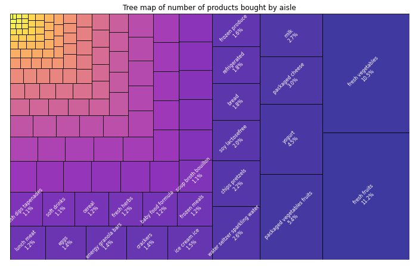

```python
#Plot pctg of items bought by department using a tree map
plt.figure(figsize=(12,8))
num_labels_in_legend = 6
legends=list(bought_by_department['name+pctg'])
ax=squarify.plot(sizes=bought_by_department['total_bought'], label=legends[:-num_labels_in_legend], alpha=.8 , color=plt.cm.plasma(np.linspace(0, 1, len(legends))), text_kwargs={'color': 'white', 'size': 10,'rotation':30},ec='black',norm_x=144, norm_y=89)
plt.axis('off')
ax.invert_xaxis()
ax.set_aspect('equal')
ax.legend(handles=ax.containers[0][:-num_labels_in_legend - 1:-1], labels=legends[:-num_labels_in_legend - 1:-1],fontsize=8,handlelength=1, handleheight=1)
plt.title('Tree map of number of products bought by department')
plt.show()

#Plot pctg of items bought by aisle using a tree map

plt.figure(figsize=(12,8))
num_labels_in_legend = 110
legends=list(bought_by_aisle['name+pctg'])
ax=squarify.plot(sizes=bought_by_aisle['total_bought'], label=legends[:-num_labels_in_legend], alpha=.8 , color=plt.cm.plasma(np.linspace(0, 1, len(legends))), text_kwargs={'color': 'white', 'size': 8,'rotation':45},ec='black',norm_x=144, norm_y=89)
plt.axis('off')
ax.invert_xaxis()
ax.set_aspect('equal')
plt.title('Tree map of number of products bought by aisle')

plt.show()
```

## 2. Clustering aisles - Reorganizing which aisles should be in the same department

The objective in this section is to compare the similarity between all the different aisles so that similar aisles are grouped together. This way it becomes much easier for customers to buy their items, as items bought together will be grouped near one another.

Two aisles are considered similar if they appear in a lot of transactions together.

Altough many different similarity measures exist, the "cosine similarity" will be used as the main metric and is discussed below. The reason why cosine similarity is the most adequate measure for this situation will also be explained.

### 2.1 Methodology: cosine similarity and ward linkage

Before calculating any metric, the data was transformed and displayed in a new format below:

Each column represents a transaction. Each row represents an aisle id (only shown until aisle 20). If the value is equal to 1, it means that a product from this aisle appeared on the transaction. As an example, for order number 5, there were products from both aisles 1 and 4.

```python
# %%
#Get all combinations of orders and aisles. This will later be used to correlate each aisle according to the orders in which they appeared together
if recalculate_group_order_aisle:
    #merging products with orders
    orders_merged=orders.merge(products,on='product_id',how='left')
    del orders

    #Counting number of products of each transaction, separated into different aisles
    count_per_order=orders_merged.groupby(['order_id','aisle_id']).count()[['product_id']].reset_index().rename(columns={'product_id':'product'})
    count_per_order['product']=1
    del orders_merged

    #Transforming each transaction into a feature.
    count_per_order=count_per_order.pivot_table(values='product',index='aisle_id',columns='order_id')

    count_per_order.to_hdf('..//processed_data/grouped_by_order_aisle.h5','main',mode='w',complib='blosc',complevel=9)
else:
    count_per_order=pd.read_hdf('..//processed_data/grouped_by_order_aisle.h5','main',mode='r')
count_per_order.head(20)
```

| order_id aisle_id | 2 | 3 | 4 | 5 | 6 | 7 | 8 | 9 | 10 | 11 | ... | 3421074 | 3421075 | 3421076 | 3421077 | 3421078 | 3421079 | 3421080 | 3421081 | 3421082 | 3421083 |
| --- | --- | --- | --- | --- | --- | --- | --- | --- | --- | --- | --- | --- | --- | --- | --- | --- | --- | --- | --- | --- | --- |
| 1 | NaN | NaN | NaN | 1.0 | NaN | NaN | NaN | NaN | NaN | NaN | ... | NaN | NaN | NaN | NaN | NaN | NaN | NaN | NaN | NaN | NaN |
| 2 | NaN | NaN | NaN | NaN | NaN | NaN | NaN | NaN | NaN | NaN | ... | NaN | NaN | NaN | NaN | NaN | NaN | NaN | NaN | NaN | NaN |
| 3 | NaN | NaN | 1.0 | NaN | NaN | NaN | NaN | NaN | NaN | NaN | ... | NaN | NaN | 1.0 | NaN | 1.0 | NaN | NaN | NaN | NaN | 1.0 |
| 4 | NaN | NaN | NaN | 1.0 | NaN | NaN | NaN | NaN | NaN | NaN | ... | NaN | NaN | NaN | NaN | NaN | NaN | NaN | NaN | NaN | NaN |
| 5 | NaN | NaN | NaN | NaN | NaN | NaN | NaN | NaN | NaN | NaN | ... | NaN | NaN | NaN | NaN | NaN | NaN | NaN | NaN | NaN | NaN |
| 6 | NaN | NaN | NaN | NaN | NaN | NaN | NaN | NaN | NaN | NaN | ... | NaN | NaN | NaN | NaN | NaN | NaN | NaN | NaN | NaN | NaN |
| 7 | NaN | NaN | NaN | NaN | NaN | NaN | NaN | NaN | NaN | NaN | ... | NaN | NaN | NaN | NaN | NaN | NaN | NaN | NaN | NaN | NaN |
| 8 | NaN | NaN | NaN | NaN | NaN | NaN | NaN | NaN | NaN | NaN | ... | NaN | NaN | NaN | NaN | NaN | NaN | NaN | NaN | NaN | NaN |
| 9 | NaN | NaN | NaN | NaN | NaN | NaN | NaN | NaN | NaN | NaN | ... | NaN | NaN | NaN | NaN | NaN | NaN | NaN | NaN | NaN | NaN |
| 10 | NaN | NaN | NaN | NaN | NaN | NaN | NaN | NaN | NaN | NaN | ... | NaN | NaN | NaN | NaN | NaN | NaN | NaN | NaN | NaN | NaN |
| 11 | NaN | NaN | 1.0 | NaN | NaN | NaN | NaN | NaN | NaN | NaN | ... | NaN | NaN | NaN | NaN | NaN | NaN | NaN | NaN | NaN | NaN |
| 12 | NaN | NaN | NaN | NaN | NaN | NaN | NaN | NaN | NaN | NaN | ... | NaN | NaN | NaN | NaN | NaN | NaN | NaN | NaN | NaN | NaN |
| 13 | NaN | NaN | NaN | NaN | NaN | NaN | NaN | NaN | NaN | NaN | ... | NaN | NaN | NaN | NaN | NaN | NaN | NaN | NaN | NaN | NaN |
| 14 | NaN | NaN | NaN | NaN | NaN | NaN | NaN | NaN | NaN | NaN | ... | 1.0 | NaN | NaN | NaN | NaN | NaN | NaN | NaN | NaN | NaN |
| 15 | NaN | NaN | NaN | NaN | NaN | NaN | NaN | NaN | NaN | NaN | ... | NaN | NaN | NaN | NaN | NaN | NaN | NaN | NaN | NaN | NaN |
| 16 | NaN | NaN | NaN | NaN | NaN | NaN | NaN | NaN | 1.0 | NaN | ... | NaN | NaN | NaN | NaN | NaN | NaN | 1.0 | NaN | NaN | NaN |
| 17 | 1.0 | NaN | NaN | NaN | NaN | NaN | NaN | NaN | NaN | NaN | ... | NaN | NaN | NaN | NaN | NaN | NaN | NaN | NaN | NaN | NaN |
| 18 | NaN | NaN | NaN | NaN | NaN | NaN | NaN | NaN | NaN | NaN | ... | NaN | NaN | NaN | NaN | NaN | NaN | NaN | NaN | NaN | NaN |
| 19 | 1.0 | NaN | NaN | NaN | NaN | NaN | NaN | 1.0 | NaN | 1.0 | ... | NaN | NaN | NaN | NaN | NaN | NaN | NaN | NaN | NaN | NaN |
| 20 | NaN | NaN | NaN | NaN | NaN | NaN | NaN | NaN | NaN | NaN | ... | NaN | NaN | NaN | NaN | NaN | NaN | NaN | NaN | NaN | NaN |

20 rows × 3214874 columns

Each row represents an aisle and each of the transactions is a property of this aisle. By comparing two rows, we are effectively comparing two aisles.

The more times both rows have a value equal to 1 (in other words, each time a transaction contains both aisles), the more similar both are to each other.

However, it is also expected that, the more times the aisle appears, the more times it will also appear with other aisles. To calculate how similar two aisles(rows) are to each other, while at the same time accounting for the fact that some aisles are much more popular than others, we use the cosine similarity:

$$cosine_{similarity}(aisle_x,aisle_y)=\frac{aisle_x*aisle_y}{\lVert aisle_x\rVert \lVert aisle_y\rVert}$$

The similarity is the vectorial product of both rows divided by their module.

Another way of visualizing the similarity between two arrays (when the arrays contain only 0s and 1s) is to use the image below:

[figure not shown]

$$cosine_{similarity}(aisle_x,aisle_y)=\frac{count(aisle_x\ \cap\ aisle_y)}{\sqrt{count(aisle_x)}*\sqrt{count(aisle_x)}}$$

So, if aisle X appeared in 200.000 transactions, aisle Y appeared in 300.000 transactions and both appeared at the same time in 50.000 transactions, then their similarity would be:

$$cosine_{similarity}(X,Y)=\frac{50.000}{\sqrt{200.000}*\sqrt{300.000}}=0.2$$

If another aisle Z appeared in 20.000 transactions and both transactions X & Y appeared 18.000 together, then the similarity would be:

$$cosine_{similarity}(X,Z)=\frac{18.000}{\sqrt{200.000}*\sqrt{20.000}}=0.28$$

This way, even though there were less transactions with both X&Z appearing than X&Y, the cosimilarity between them was higher and both aisles are expected to be grouped closer.

The cosine similarity is ideal for this application as:

1. The data is very unbalanced: some aisles appear in much more transactions than others, so it normalizes to account for different magnitudes in scale.
2. There are a great number of attributes (transactions) and the data is very sparse (lots of 0s): cosine similarity is much more useful in these cases when compared to other metrics (such as correlation, jaccard index, hamming distance, etc).

```python
#Calculate cosine similarity between each aisle
if recalculate_cosine_similarity:
    #iterate through each aisle number and calculate the cosine similarity with all other aisles
    n_isles=len(count_per_order.index)
    cosine_similarity_matrix=np.zeros((n_isles+1,n_isles+1))
    for aisle_id_i in np.arange(1,n_isles+1):
        for aisle_id_j in np.arange(aisle_id_i,n_isles+1):
            cosine_similarity_matrix[aisle_id_i][aisle_id_j]=cosine_similariy(count_per_order.loc[aisle_id_i,:],count_per_order.loc[aisle_id_j,:])
            cosine_similarity_matrix[aisle_id_j][aisle_id_i]=cosine_similariy(count_per_order.loc[aisle_id_i,:],count_per_order.loc[aisle_id_j,:])

    #disconsidering index 0, as there was no aisle with index 0
    cosine_similarity_matrix=cosine_similarity_matrix[1:,1:]

    #saving data for later retrieval
    with open('../processed_data/cosine_similarity_matrix.npy', 'wb') as f:
        np.save(f, cosine_similarity_matrix)
else:
    #loading data processed in a previous run of the program
    with open('../processed_data/cosine_similarity_matrix.npy', 'rb') as f:
        cosine_similarity_matrix=np.load(f)
```

```python
#show cosine similarity matrix
pd.DataFrame(cosine_similarity_matrix).head(5)
```

|  | 0 | 1 | 2 | 3 | 4 | 5 | 6 | 7 | 8 | 9 | ... | 124 | 125 | 126 | 127 | 128 | 129 | 130 | 131 | 132 | 133 |
| --- | --- | --- | --- | --- | --- | --- | --- | --- | --- | --- | --- | --- | --- | --- | --- | --- | --- | --- | --- | --- | --- |
| 0 | 1.000000 | 0.032569 | 0.055911 | 0.045042 | 0.021629 | 0.017815 | 0.018361 | 0.031198 | 0.049523 | 0.004462 | ... | 0.015996 | 0.007958 | 0.010369 | 0.045377 | 0.048638 | 0.032967 | 0.043157 | 0.005679 | 0.010656 | 0.005565 |
| 1 | 0.032569 | 1.000000 | 0.049812 | 0.051492 | 0.033980 | 0.018284 | 0.026632 | 0.021230 | 0.071663 | 0.009570 | ... | 0.012246 | 0.009428 | 0.013388 | 0.060933 | 0.048365 | 0.040014 | 0.077741 | 0.007821 | 0.010257 | 0.008943 |
| 2 | 0.055911 | 0.049812 | 1.000000 | 0.109156 | 0.043039 | 0.037601 | 0.031396 | 0.037310 | 0.101119 | 0.012309 | ... | 0.077220 | 0.022392 | 0.032834 | 0.096098 | 0.105417 | 0.104441 | 0.104818 | 0.015213 | 0.024213 | 0.007953 |
| 3 | 0.045042 | 0.051492 | 0.109156 | 1.000000 | 0.077282 | 0.033855 | 0.038155 | 0.029045 | 0.133949 | 0.015824 | ... | 0.035187 | 0.026549 | 0.049211 | 0.106266 | 0.142234 | 0.085391 | 0.138506 | 0.016085 | 0.022613 | 0.011668 |
| 4 | 0.021629 | 0.033980 | 0.043039 | 0.077282 | 1.000000 | 0.021705 | 0.031613 | 0.016104 | 0.075582 | 0.019221 | ... | 0.013004 | 0.013276 | 0.028279 | 0.070498 | 0.067132 | 0.043363 | 0.077763 | 0.007150 | 0.010737 | 0.008200 |

5 rows × 134 columns

After arriving at the cosine similarity matrix, to obtain the distance matrix, which is used in agglomerative clustering algorithms, one must perform the operation:

$$distance_{matrix}=1-cosimilarity_{matrix}$$

With the distance matrix, we can begin the use of agglomerative clustering, a type of hierarchical clustering algorithm. It has a bottom-up approach:

1. Each aisle forms a cluster.
2. All clusters are compared to each other. The closest two clusters (lowest distance) are then united into a new cluster/group.
3. Repeat until all objects are united in a single cluster. As groups begin having multiple objects inside, some distance function must be used to measure the distance between clusters (distance of a group of objects to another group of objects). This is called a linkage function, some of the possible linkages used are:
- Single linkage: Minimum distance between two objects of compared groups.
- Complete linkage: Maximum distance between two objects of compared groups.
- Average linkage: Average distance between objects of compared groups.
- Ward linkage: Aims to minimize quadratic error (intra-group variance)

All linkage methods were tested. The best results were obtained with ward linkage.

### 2.2 Hierarchical clustering of aisles

The result of hierarchical clustering of the aisles, using ward linkage and cosine similarity as the dis(similarity) metric, is shown below, which was cut at distance equal to 1.5, creating 17 clusters:

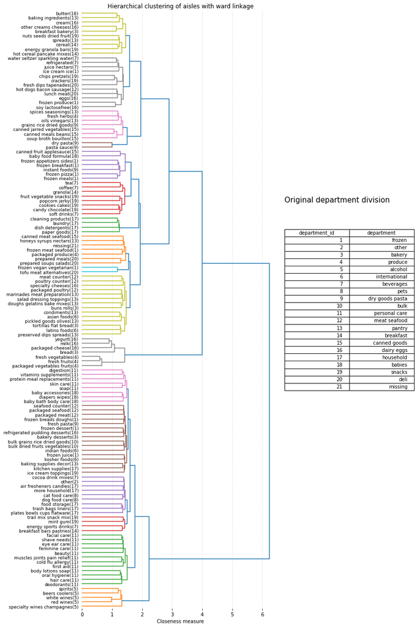

```python
#using the precomputed cosine matrix and using complete linkage to group items together, plot the hierarchical structure using a dendogram
clustering2=AgglomerativeClustering(n_clusters=10,affinity='precomputed',linkage='complete').fit(1-cosine_similarity_matrix)

plt.figure(figsize=(12,18))
gspec= gridspec.GridSpec(80,10)

left_ax= plt.subplot(gspec[:,:6])
right_ax=plt.subplot(gspec[:,6:])

#calculate linkage matrix using wards method
linkage_matrix = linkage(1-cosine_similarity_matrix, "ward")
dend=dendrogram(linkage_matrix,truncate_mode='level',orientation='right',labels=list(aisle_name_with_dep_id),color_threshold=1.5,ax=left_ax)
left_ax.spines['right'].set_visible(False)
left_ax.spines['top'].set_visible(False)
left_ax.spines['left'].set_visible(False)
left_ax.spines['bottom'].set_visible(False)
left_ax.tick_params(axis='y', which='major', labelsize=9)
left_ax.set_xlabel('Closeness measure')
left_ax.xaxis.grid(True,linestyle='--',alpha=0.4)
left_ax.set_title('Hierarchical clustering of aisles with ward linkage')
cell_text = []
for row in range(len(departments)):
    cell_text.append(departments.iloc[row])
right_ax.table(cellText=cell_text, colLabels=departments.columns, loc='center')
right_ax.annotate('Original department division',(0,0.68),fontsize=15)
plt.axis('off')
plt.tight_layout()
plt.savefig('clustering_aisles.jpg',dpi=200)
del cosine_similarity_matrix,linkage_matrix
```

From the hierarchical analysis, some aisle placement strategies become more clear:

1. The closest aisles should be vegetables and fruits, together with breakfast related items. Bread should also be put near other breakfast related items. (bottom grey group)
2. Interestingly, Frozen vegan foods should be grouped with tofu and meat alternatives, indicating the presence of vegan customers (light blue group).
3. A junk food section (top grey group) could be created: drinks, snacks, ice cream and cakes were normally bought together.
4. Instant foods should be moved into department of frozen prepared meals (top purple group)
5. A department of condiments/spices/seasoning could be interesting (top pink group)

So, even though the data may point to a relation, this relation may not have a real interpretation: in the same way **"correlation does not imply causation"**, it is possible to say **"computational similarity does not imply association"**.

## 3. Assigning products with missing information to an aisle using cosimilarity

The dataset had a total of **1803** out of **49677** products that had no specific aisle assignment.

By using clustering analysis it is possible to assign each product to the most similar aisle. This is done using a methodology very similar to the previous items:

1. The cosine similarity between a product id and an aisle is calculated for all missing products and all aisles.
2. Each product is then assigned to the aisle that it had the highest similarity to.

All the missing product and respective aisles to which they were assigned are shown below.

```python
del count_per_order

#####PART 2 - ASSIGNING OTHERS AND MISSING TO OTHER SECTION#######
if recalculate_aisle_assignment:
    #%%
    #remaking aisles so that each item in aisle "other" or "missing" is considered as a separate aisle
    aisles=complete_orders['aisle']
    products=complete_orders['product_name']
    aisle_ids=complete_orders['aisle_id']
    combined_data=np.transpose([aisles,products,aisle_ids])
    del aisles,products,aisle_ids

    remade_aisles=list(map(lambda x:x[1] if x[2] in [6,100] else x[0],combined_data))

    complete_orders['remade_aisles']=remade_aisles
    #%%
    #Obtaining all aisles and order_ids that happened together
    count_per_order2=complete_orders.groupby(['order_id','remade_aisles']).count()[['product_id']].reset_index().rename(columns={'product_id':'product'})
    count_per_order2['product']=1


    #creating new dictionary considering products as aisles. Keep original aisles (aisles 1 to 21) identification. In the dictionary: Aisle_name as key, Aisle_id as value
    aisles_custom=list(set(pd.unique(count_per_order2['remade_aisles']))-set(aisles_dict.values()))
    aisles_custom.sort()
    aisles_dict_custom=dict(zip(aisles_custom,np.arange(len(aisles_dict)+1,len(aisles_dict)+1+len(aisles_custom))))

    inverted_aisles_dict=invert_dictionary(aisles_dict)

    aisles_dict_unified={**inverted_aisles_dict, **aisles_dict_custom}

    inverted_aisles_dict_unified={v: k for k, v in aisles_dict_unified.items()}

    #Adding remade aisle ids to dataframe
    count_per_order2['aisle_id_custom']=list(map(lambda x:aisles_dict_unified[x],count_per_order2['remade_aisles']))

    #%%

    #creating a dictionary. Each key is a transaction. Each value is the list of aisles in the transaction
    orders_aisles_list=np.transpose([list(count_per_order2['order_id']),list(count_per_order2['aisle_id_custom'])])
    dict_transactions={}
    for order_id in count_per_order2['order_id']:
        dict_transactions[order_id]=[]
    for item in orders_aisles_list:
        dict_transactions[item[0]]+=[item[1]]

    del count_per_order2
    #total number of new aisles (original aisles+products with no aisle assignment)
    number_unique_aisles_custom=len(aisles_dict_unified)

    #For each transaction, check which aisles appeared together to form a matrix that will be used to calculate the cosine similarity matrix

    common_appearances_matrix=np.zeros((number_unique_aisles_custom,number_unique_aisles_custom))
    total_count=np.zeros(number_unique_aisles_custom)

    #iterating through transactions
    for transaction in dict_transactions:

        aisles_this_trans=np.array(dict_transactions[transaction])
        #we are only interested in combinations of nonmain_aisles (from "missing" and "other" groups) and main aisles (frozen, bakery,etc)
        main_aisles_transactions=aisles_this_trans[aisles_this_trans<=len(aisles_dict)]
        nonmain_aisles_transactions=aisles_this_trans[aisles_this_trans>len(aisles_dict)]

        #add to respective index in 1D array each time an aisle appeared in a transaction
        for aisle_custom_id in aisles_this_trans:
            total_count[aisle_custom_id-1]+=1
            common_appearances_matrix[aisle_custom_id-1,aisle_custom_id-1]+=1

        #add to respective index in DD array each time two aisaislesles appeared simultaneously in a transaction

        for combination in list(itertools.product(nonmain_aisles_transactions,main_aisles_transactions)):
            common_appearances_matrix[combination[0]-1,combination[1]-1]+=1
            common_appearances_matrix[combination[1]-1,combination[0]-1]+=1
    del dict_transactions
    #calculating cosine similarity between each aisle
    cosine_similarity_matrix=common_appearances_matrix.copy()
    for i in np.arange(0,len(total_count)):
        for j in np.arange(0,len(total_count)):
            if i==j:
                cosine_similarity_matrix[i][j]=1
            else:
                cosine_similarity_matrix[i][j]=cosine_similarity_matrix[i][j]/(np.sqrt(total_count[i])*np.sqrt(total_count[j]))
    del common_appearances_matrix

    #iterate through each custom aisle (items that had no aisle assignment) and get original aisle (21 original aisles) that has the highest similarity to the product.
    #The product is then assigned to this section.
    aisle_assignment=[]
    for index in np.arange(len(aisles_dict),len(aisles_dict)+len(aisles_custom)):
        cosine_sim_this_custom_aisle=cosine_similarity_matrix[index]

        max_value=0
        count=0
        for cosine_similarity in cosine_sim_this_custom_aisle:
            if cosine_similarity>max_value and cosine_similarity!=1:
                max_value=cosine_similarity
                index_selected=count
            count+=1
        aisle_assignment+=[[inverted_aisles_dict_unified[index+1], inverted_aisles_dict_unified[index_selected+1],max_value]]
    del cosine_similarity_matrix
    aisle_assignment=pd.DataFrame(aisle_assignment,columns=['Product','Aisle Assigned','Cosine Similarity'])

    #Add extra information to the aisle assignment dataframe: number of transactions the product appeared on
    item_count=complete_orders[complete_orders['department_id'].apply(lambda x: x in [2,21])].groupby(['product_name','aisle']).count()[['order_id']].reset_index().rename(columns={'order_id':'number of transactions that had item','product_name':'Product','aisle':'aisle_origin'})

    del complete_orders

    aisle_assignment=aisle_assignment.merge(item_count,on='Product').sort_values(by='Cosine Similarity',ascending=False).reset_index(drop=True)

    aisle_assignment.to_csv('../processed_data/aisle_assignment_missing.csv')
    with open('../processed_data/aisles_dict_unified.pkl','wb') as fp:
        pickle.dump(aisles_dict_unified, fp)
else:
    aisle_assignment=pd.read_csv('../processed_data/aisle_assignment_missing.csv',index_col=0)
    with open('../processed_data/aisles_dict_unified.pkl','rb') as fp:
        aisles_dict_unified=pickle.load(fp)
```

```python
pd.set_option('display.max_rows', 1805)

aisle_assignment.sort_values(by='Cosine Similarity',ascending=False).reset_index(drop=True).head(200)
```

|  | Product | Aisle Assigned | Cosine Similarity | aisle_origin | number of transactions that had item | product_id | aisle_id |
| --- | --- | --- | --- | --- | --- | --- | --- |
| 0 | Organic Riced Cauliflower | fresh vegetables | 0.059284 | missing | 8366 | 41149 | 83 |
| 1 | Pinot Noir Rose | white wines | 0.055683 | other | 382 | 31113 | 62 |
| 2 | The Original Margarita Mix | spirits | 0.053810 | other | 136 | 27936 | 124 |
| 3 | Margarita Salt | spirits | 0.050017 | other | 129 | 27371 | 124 |
| 4 | White Apple Cauliflower & Leek Organic Baby Food | baby food formula | 0.047781 | missing | 424 | 1387 | 92 |
| 5 | Peanut Butter Ice Cream Cup | ice cream ice | 0.046260 | missing | 1933 | 7035 | 37 |
| 6 | Eat Your Colors Purples Puree Baby Food | baby food formula | 0.044554 | missing | 381 | 20153 | 92 |
| 7 | Eat Your Colors Reds Puree Baby Food | baby food formula | 0.041113 | missing | 333 | 46949 | 92 |
| 8 | Classic Margarita Mix | spirits | 0.040481 | other | 72 | 19463 | 124 |
| 9 | Facial Mask Age Defying Hydro Serum | beauty | 0.040094 | other | 47 | 34404 | 132 |
| 10 | Cookie Dough Ice Cream Chocolate Chip | ice cream ice | 0.039618 | missing | 1311 | 11494 | 37 |
| 11 | Natural Lemon Flavored Sparkling Water | water seltzer sparkling water | 0.038841 | missing | 1455 | 10690 | 115 |
| 12 | Stage 2 Eat Your Colors Organic, Green: Pea, K... | baby food formula | 0.038249 | missing | 309 | 33668 | 92 |
| 13 | Protein Bar Maple Sea Salt | energy granola bars | 0.036342 | missing | 609 | 45311 | 3 |
| 14 | Roasted Almond Butter | fresh fruits | 0.036193 | other | 3976 | 38662 | 24 |
| 15 | Brightening Hydro Serum Facial Mask | beauty | 0.034996 | other | 74 | 18255 | 132 |
| 16 | Aromatic Bitters | spirits | 0.034522 | other | 99 | 14078 | 124 |
| 17 | Protein Bar Mint Chocolate | energy granola bars | 0.032518 | missing | 448 | 18542 | 3 |
| 18 | Organic Mango Yogurt | yogurt | 0.030212 | missing | 1675 | 14010 | 120 |
| 19 | Maple Almond Bar | energy granola bars | 0.030160 | missing | 337 | 2592 | 3 |
| 20 | S'mores Ice Cream | ice cream ice | 0.029956 | missing | 686 | 36029 | 37 |
| 21 | Pulled Porkless Pocket Meals | frozen vegan vegetarian | 0.029806 | missing | 138 | 21747 | 42 |
| 22 | Organic Celery Bunch | fresh vegetables | 0.029632 | missing | 1645 | 38510 | 83 |
| 23 | Recolte Wine | white wines | 0.028807 | other | 166 | 7004 | 62 |
| 24 | Bold & Spicy Bloody Mary Mix | spirits | 0.028603 | other | 108 | 10524 | 124 |
| 25 | Whispering Angel Rosé | red wines | 0.028460 | other | 153 | 37389 | 28 |
| 26 | Grenadine Syrup | spirits | 0.028342 | other | 110 | 38088 | 124 |
| 27 | California Blush Pink Champagne | specialty wines champagnes | 0.028110 | other | 37 | 24603 | 134 |
| 28 | Bloody Mary Mix | spirits | 0.027316 | other | 190 | 34680 | 124 |
| 29 | Strained Non-Fat Strawberry Icelandic Style Sk... | yogurt | 0.026899 | missing | 750 | 30563 | 120 |

[output cut: 170 more lines]

It is possible to see that the products which had the most amount of transactions and had a high value of cosine similarity were most likely to be assigned to a correct section. The first item, cauliflower, was correctly grouped with vegetables for example.

Some items were also wrongly assigned, such as Roasted Almond Butter (row 14), which was assigned to the fruits aisle.

Ideally, the aisle assignment would also use some sort of Natural Language processing strategy to assign the items. However, as the objective of this study is to study the potential of clustering solutions, we won't dive into this approach.

From this section onwards, all analysis will consider these products in the new aisle assigned.

## 3. Clustering departments and optimizing marketing layout

In this section, similar to section 2, the departments will be clustered accordingly to the similarity between themselves. The idea is to have similar departments close to each other.

Next, based on both the department similarity and the department importance (which will be measured by number of items sold), we will draw how the supermarket should be mapped:

- Which departments are closer to the entrance?
- Which departments are near each other?

### 3.1 Clustering departments

The data was processed to understand which departments happened in each transaction. A table with this information is shown below.

For transaction 10, for example, items from departments 4 (produce), 12 (meat seafood), 15 (canned goods), 16 (dairy eggs) and 18 (babies) were bought.

```python
#####PART 3 - Clustering departments

#making dictionary with equivalency between product id and new aisle to which they are assigned
aisle_assignment['product_id']=aisle_assignment['Product'].apply(lambda x:product_dict[x])


aisle_assignment['aisle_id']=aisle_assignment['Aisle Assigned'].apply(lambda x:aisles_dict_unified[x])

new_aisle_assignment_dict=dict(zip(aisle_assignment['product_id'],aisle_assignment['aisle_id']))

#
orders=pd.read_csv('../data/order_products__prior.csv')[['order_id','product_id']]
products=pd.read_csv('../data/products.csv')
aisles=pd.read_csv('../data/aisles.csv')
departments=pd.read_csv('../data/departments.csv')

products['new_aisle_id']=products.apply(lambda x:new_aisle_assignment_dict[x['product_id']] if x['product_id'] in new_aisle_assignment_dict else x['aisle_id'],axis=1)
products['new_department_id']=products['new_aisle_id'].apply(lambda x:aisle_dept_dict[x])
products.to_csv('../processed_data/reassigned_products.csv')
if recalculate_group_order_department:
    #merging products with orders
    orders_merged=orders.merge(products,on='product_id',how='left')
    del orders

    #Counting number of products of each transaction, separated into different aisles
    count_per_order=orders_merged.groupby(['order_id','new_department_id']).count()[['product_id']].reset_index().rename(columns={'product_id':'product'})
    count_per_order['product']=1
    del orders_merged

    #Transforming each transaction into a feature.
    count_per_order=count_per_order.pivot_table(values='product',index='new_department_id',columns='order_id')

    count_per_order.to_hdf('..//processed_data/grouped_by_order_department.h5','main',mode='w',complib='blosc',complevel=9)
else:
    count_per_order=pd.read_hdf('..//processed_data/grouped_by_order_department.h5','main',mode='r')
count_per_order
```

| order_id new_department_id | 2 | 3 | 4 | 5 | 6 | 7 | 8 | 9 | 10 | 11 | ... | 3421074 | 3421075 | 3421076 | 3421077 | 3421078 | 3421079 | 3421080 | 3421081 | 3421082 | 3421083 |
| --- | --- | --- | --- | --- | --- | --- | --- | --- | --- | --- | --- | --- | --- | --- | --- | --- | --- | --- | --- | --- | --- |
| 1 | NaN | NaN | NaN | NaN | NaN | 1.0 | NaN | NaN | NaN | 1.0 | ... | 1.0 | NaN | NaN | NaN | NaN | NaN | 1.0 | NaN | NaN | 1.0 |
| 3 | NaN | 1.0 | 1.0 | NaN | NaN | NaN | 1.0 | 1.0 | NaN | NaN | ... | NaN | NaN | NaN | NaN | NaN | NaN | NaN | 1.0 | NaN | NaN |
| 4 | 1.0 | 1.0 | NaN | 1.0 | NaN | NaN | NaN | 1.0 | 1.0 | NaN | ... | 1.0 | NaN | NaN | 1.0 | 1.0 | NaN | 1.0 | NaN | 1.0 | 1.0 |
| 5 | NaN | NaN | NaN | NaN | NaN | NaN | NaN | NaN | NaN | NaN | ... | NaN | NaN | NaN | NaN | NaN | NaN | NaN | NaN | NaN | NaN |
| 6 | NaN | NaN | NaN | 1.0 | NaN | NaN | NaN | NaN | NaN | NaN | ... | NaN | NaN | NaN | NaN | NaN | NaN | NaN | NaN | NaN | NaN |
| 7 | NaN | NaN | 1.0 | 1.0 | 1.0 | 1.0 | NaN | 1.0 | NaN | NaN | ... | NaN | 1.0 | 1.0 | NaN | NaN | NaN | 1.0 | 1.0 | NaN | NaN |
| 8 | NaN | NaN | NaN | NaN | NaN | NaN | NaN | NaN | NaN | NaN | ... | NaN | NaN | NaN | NaN | NaN | NaN | NaN | NaN | NaN | NaN |
| 9 | NaN | NaN | NaN | 1.0 | NaN | NaN | NaN | NaN | NaN | NaN | ... | NaN | NaN | NaN | NaN | NaN | NaN | NaN | NaN | NaN | NaN |
| 10 | NaN | NaN | NaN | NaN | NaN | NaN | NaN | NaN | NaN | NaN | ... | NaN | NaN | NaN | NaN | NaN | NaN | NaN | NaN | NaN | NaN |
| 11 | NaN | NaN | 1.0 | 1.0 | NaN | NaN | NaN | NaN | NaN | NaN | ... | NaN | NaN | NaN | NaN | NaN | 1.0 | NaN | NaN | NaN | NaN |
| 12 | NaN | 1.0 | NaN | 1.0 | NaN | NaN | NaN | NaN | 1.0 | NaN | ... | NaN | NaN | 1.0 | NaN | NaN | NaN | NaN | NaN | 1.0 | NaN |
| 13 | 1.0 | NaN | NaN | 1.0 | NaN | NaN | NaN | 1.0 | NaN | 1.0 | ... | NaN | NaN | 1.0 | NaN | NaN | NaN | NaN | 1.0 | NaN | NaN |
| 14 | NaN | NaN | 1.0 | NaN | NaN | NaN | NaN | 1.0 | NaN | NaN | ... | NaN | 1.0 | NaN | NaN | 1.0 | NaN | NaN | NaN | 1.0 | NaN |
| 15 | NaN | NaN | NaN | NaN | NaN | NaN | NaN | 1.0 | 1.0 | 1.0 | ... | NaN | NaN | 1.0 | NaN | NaN | NaN | NaN | 1.0 | NaN | NaN |
| 16 | 1.0 | 1.0 | NaN | 1.0 | NaN | NaN | NaN | 1.0 | 1.0 | NaN | ... | 1.0 | NaN | 1.0 | 1.0 | 1.0 | NaN | 1.0 | 1.0 | 1.0 | NaN |
| 17 | NaN | NaN | NaN | 1.0 | 1.0 | NaN | NaN | NaN | NaN | NaN | ... | NaN | NaN | NaN | NaN | NaN | NaN | NaN | NaN | NaN | 1.0 |
| 18 | NaN | NaN | NaN | NaN | NaN | NaN | NaN | NaN | 1.0 | NaN | ... | NaN | NaN | NaN | NaN | NaN | NaN | NaN | NaN | NaN | 1.0 |
| 19 | NaN | NaN | 1.0 | 1.0 | NaN | NaN | NaN | 1.0 | NaN | 1.0 | ... | NaN | 1.0 | 1.0 | NaN | 1.0 | NaN | NaN | 1.0 | 1.0 | 1.0 |
| 20 | NaN | NaN | NaN | 1.0 | NaN | NaN | NaN | NaN | NaN | 1.0 | ... | 1.0 | NaN | NaN | NaN | 1.0 | NaN | NaN | 1.0 | NaN | NaN |

19 rows × 3214874 columns

With this data, the cosine similarity between aisles was calculated and they were grouped using an agglomerative clustering algorithm using ward linkage. The result is shown below:

```python
#Calculate cosine similarity between each aisle
if recalculate_cosine_similarity_dept:
    #iterate through each aisle number and calculate the cosine similarity with all other aisles
    n_depts=len(count_per_order.index)
    cosine_similarity_matrix=np.zeros((n_depts+2,n_depts+2))
    for dept_id_i in np.arange(1,n_depts+2):
        for dept_id_j in np.arange(dept_id_i,n_depts+2):
            if dept_id_i==2 or dept_id_j==2:continue
            cosine_similarity_matrix[dept_id_i][dept_id_j]=cosine_similariy(count_per_order.loc[dept_id_i,:],count_per_order.loc[dept_id_j,:])
            cosine_similarity_matrix[dept_id_j][dept_id_i]=cosine_similariy(count_per_order.loc[dept_id_i,:],count_per_order.loc[dept_id_j,:])

    #disconsidering index 0, as there was no aisle with index 0
    cosine_similarity_matrix=cosine_similarity_matrix[1:,1:]

    #saving data for later retrieval
    with open('../processed_data/cosine_similarity_matrix_dept.npy', 'wb') as f:
        np.save(f, cosine_similarity_matrix)
else:
    #loading data processed in a previous run of the program
    with open('../processed_data/cosine_similarity_matrix_dept.npy', 'rb') as f:
        cosine_similarity_matrix=np.load(f)
del count_per_order
```

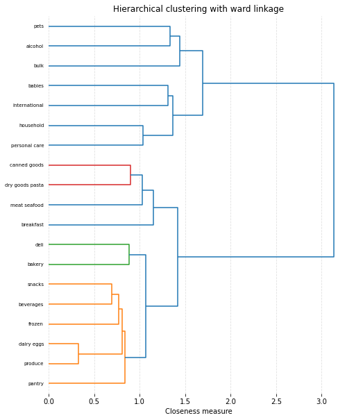

```python
#deleting second item, as it includes "other" department, which does not exist anymore
cosine_similarity_matrix=np.delete(np.delete(cosine_similarity_matrix,1,0),1,1)
#%%
#using the precomputed cosine matrix and using complete linkage to group items together, plot the hierarchical structure using a dendogram
clustering2=AgglomerativeClustering(n_clusters=10,affinity='precomputed',linkage='complete').fit(1-cosine_similarity_matrix)

plt.figure(figsize=(8,10))
gspec= gridspec.GridSpec(80,30)

left_ax= plt.subplot(gspec[:,:29])
right_ax=plt.subplot(gspec[:,29:])

labels=list(departments_dict.values())
labels=[labels[0]]+labels[2:-1]

#calculate linkage matrix using wards method
linkage_matrix = linkage(1-cosine_similarity_matrix, "ward")
dend=dendrogram(linkage_matrix,truncate_mode='level',orientation='right',labels=labels,color_threshold=1,ax=left_ax)
left_ax.spines['right'].set_visible(False)
left_ax.spines['top'].set_visible(False)
left_ax.spines['left'].set_visible(False)
left_ax.spines['bottom'].set_visible(False)
left_ax.tick_params(axis='y', which='major', labelsize=7)
left_ax.set_xlabel('Closeness measure')
left_ax.xaxis.grid(True,linestyle='--',alpha=0.4)
left_ax.set_title('Hierarchical clustering with ward linkage')
cell_text = []
for row in range(len(departments)):
    cell_text.append(departments.iloc[row])
plt.axis('off')
plt.tight_layout()
plt.savefig('clustering_depts.jpg',dpi=200)
```

What the dendogram aboves tell us is that "dairy eggs" and "produce" should be grouped together. Next, "snacks" and "beverages" form a new group. Third, "frozen" is added next to "snacks" and "beverages".

This information will be useful when organizing the layout of the store.

### 3.2 Market Layout

To optimize the market layout, we will consider that the store consists of 18 departments, displayed on a 3x6 grid. Such as the example below.

[figure not shown]

The objective on the planning of the market layout is to improve efficiency for customers, allowing for customers to quickly fill their wanted basket. To achieve that:

1. Similar sections should be grouped together. (based on clustering graph above)
2. The most important sections are closer to the center and closer to the entrance. (we will use number of items bought by department as the importance metric - this criteria follows the graphs plotted in section 1, which found that produce, dairy eggs and snacks were among the most important departments.)

This is reflected in the figure above: The lower the number of the square, the more important we consider this segment and the more important sections should be placed there.

Following both rules, the following market layout is proposed:

[figure not shown]

Obs: Bulk and international were grouped together as they both had very few items and it was necessary to reduce 19 departments down to 18 to fit the 3x6 grid.

### 3.3 Other Market Layout strategies

While the design presented aims to improve customer efficiency in the market, different strategies could be used.

If for example the objective was to incentivize the customer to buy items they were not intended on buying (incentivizing impulse buying), one could model the layout to maximize walking distance in the supermarket: the most important departments would be in the back and departments with high similarity would be on opposite sides of the market.

Altough this strategy could increase impulsive buying it could also lead to lower customer satisfaction and lower number of customers in the long term.

## 4. Selecting products to be displayed near supermarket cashier counters

Finally, the last step on the market planning is to select the items that should be displayed near the cashier counters. These items are either items likely to be impulse bought or items from a section that a customer may not have passed through.

[figure not shown]

Ideally a item would be displayed near the counters if it had the following characteristics:

1. It is a popular item.
2. It normally is the unique item from a department in a given transaction.
3. It has a higher similarity to other departments than its own.

Before trying to establish a metric for the three criteria, the data was processed so that useful information could be extracted:

- How many transactions it appeared on?
- How many transactions it was the sole product of its own department?
- How many transactions it occured with other departments.

This information is shown below for the first three items. As an example, product 28985 of department 4:

- Occurred in 67449 transactions.
- Occured in 2130 transactions as the sole product of department 4.
- Occured 65319 times with other products of department 4.
- Occured 31617 times with products of department 1.

```python
# 4 - Getting items to display in front based on how many times they happened, as well as how much uncorrelated to their department they are.

orders=pd.read_csv('../data/order_products__prior.csv')[['order_id','product_id']]
products=pd.read_csv('../processed_data/reassigned_products.csv',index_col=0)
orders_merged=orders.merge(products,on='product_id',how='left')
del orders,products
new_dept_assignment_dict=dict(zip(orders_merged['product_id'],orders_merged['new_department_id']))

unique_products_dep=orders_merged[['product_id','department_id']].drop_duplicates()
product_dept_dict=dict(zip(unique_products_dep['product_id'],unique_products_dep['department_id']))

if recalculate_dept_product_dict:
    count_per_order3=orders_merged.groupby(['order_id','new_department_id']).count()[['product_id']].reset_index().rename(columns={'product_id':'product'})

    orders_dept_list=np.transpose([list(count_per_order3['order_id']),list(count_per_order3['new_department_id']),list(count_per_order3['product'])])
    dict_transactions_dept={}
    for order_id in count_per_order3['order_id']:
        dict_transactions_dept[order_id]={}
        dict_transactions_dept[order_id]['departments']=[]
        dict_transactions_dept[order_id]['n_items']=[]

    for item in orders_dept_list:
        dict_transactions_dept[item[0]]['departments']+=[item[1]]
        dict_transactions_dept[item[0]]['n_items']+=[item[2]]

    dict_product_departments={}
    for prod_id in pd.unique(orders_merged['product_id']):
        dict_product_departments[prod_id]={}
        dict_product_departments[prod_id]['occurrences_with_dep']=np.zeros(len(departments)+1)
        dict_product_departments[prod_id]['occurrences']=0
        dict_product_departments[prod_id]['occurrences_alone_in_section']=0
        dict_product_departments[prod_id]['department']=product_dept_dict[prod_id]



    for index,row in orders_merged.iterrows():
        if index%100000==0:
            print(index//100000,end=', ')

        dict_product_departments[row['product_id']]['occurrences']+=1
        department_product=row['new_department_id']

        # if item is the only item of a department that appears in an order, add 1 to "occurrences_alone_in_section"
        if department_product in dict_transactions_dept[row['order_id']]['departments']:
            index_in_list=dict_transactions_dept[row['order_id']]['departments'].index(department_product)
            if dict_transactions_dept[row['order_id']]['n_items'][index_in_list]==1:
                dict_product_departments[row['product_id']]['occurrences_alone_in_section']+=1

        item_length=len(dict_transactions_dept[row['order_id']]['departments'])
        for i in np.arange(item_length):
            dept=dict_transactions_dept[row['order_id']]['departments'][i]
            n_items=dict_transactions_dept[row['order_id']]['n_items'][i]
            #dict_product_departments[row['product_id']]['occurrences_with_dep'][dept]+=n_items

            #skip in case the product is the only one of the department
            if dept == department_product and n_items==1:continue

            dict_product_departments[row['product_id']]['occurrences_with_dep'][dept]+=1


    with open('../processed_data/dict_product_departments.pkl','wb') as fp:
        pickle.dump(dict_product_departments, fp)
else:
    with open('../processed_data/dict_product_departments.pkl','rb') as fp:
        dict_product_departments=pickle.load(fp)
```

```python
#print first 3 items of dictionary
dict(list(dict_product_departments.items())[0:3])
```

```
{33120: {'occurrences_with_dep': array([0.0000e+00, 9.3190e+03, 0.0000e+00, 6.2720e+03, 1.7757e+04,
         1.0000e+00, 1.7670e+03, 8.9980e+03, 1.5600e+02, 4.3380e+03,
         3.4600e+02, 1.7700e+03, 5.6180e+03, 8.2890e+03, 3.7330e+03,
         5.3230e+03, 1.5661e+04, 1.8520e+03, 1.1910e+03, 9.0230e+03,
         6.9770e+03, 0.0000e+00]),
  'occurrences': 19400,
  'occurrences_alone_in_section': 3739,
  'department': 16},
 28985: {'occurrences_with_dep': array([    0., 31617.,     0., 21471., 65319.,   410.,  7919., 30574.,
           846., 19207.,  1636.,  6860., 17585., 30950., 12580., 23847.,
         53851.,  8079.,  4443., 32420., 23400.,     0.]),
  'occurrences': 67449,
  'occurrences_alone_in_section': 2130,
  'department': 4},
 9327: {'occurrences_with_dep': array([   0., 3026.,    0., 2050., 5532.,  138.,  949., 2898.,  124.,
         2183.,   91.,  751., 2026., 4823., 1149., 2757., 4917., 1272.,
          347., 2860., 1782.,    0.]),
  'occurrences': 6299,
  'occurrences_alone_in_section': 1476,
  'department': 13}}
```

With this information it was then possible to calculate key metrics to reach the characteristics judged important:

1. Popular item - number of occurrences in transactions. The higher the value the lower the rank.
2. Unique product of department in transactions: % of time it appeared as the single item from a department. The higher the percentage the lower the rank.
3. Higher similarity to other departments.The lower the value of the ratio, the lower the rank: $$\frac{cosine_{similarity}\ with\ own\ department}{median\ cosine_{similarity}\ with\ other\ departments}$$

All 3 metrics were calculated for each product and ranked. To account for all three metrics, a summed rank was made, which was used to select the top 100 product suggestions to go near the counters, shown in the table below.

As an example, the first suggestion, dried mango:

- Appeared in 10150 transactions, which placed it in the 487th rank for the first criteria.
- For the transactions it appeared, 97.5% of the time it was the only item from the "bulk department", which placed it in 235th rank for the second criteria.
- Had a ratio of 0.7 between the cosimilarity with its own department and the median cosimilarity with the other departments, which placed it in the 383th rank for the third criteria.
- The final rank was equal to 487+235+383=1105th. As this was the lowest rank from the final metric, the product was selected to be placed near the counters.

Interestingly, there were a lot of items from the "bulk" department, as well as bread/bakery and snacks items.

```python
#counting number of times dept appears
occurences_by_dep={}
for i in np.arange(len(departments)+1):
    occurences_by_dep[i]=0

for dept_id in orders_merged['new_department_id']:
    occurences_by_dep[dept_id]+=1
#%%
#getting product id to dept id assignment
# %%

# %%
product_info=[]
for product_id in new_dept_assignment_dict:

    dept_id_of_product=new_dept_assignment_dict[product_id]

    total_occur=dict_product_departments[product_id]['occurrences']
    occurences_other_depts=dict_product_departments[product_id]['occurrences_with_dep']

    occurences_unique_in_dept=dict_product_departments[product_id]['occurrences_alone_in_section']
    ptcg_unique_in_section=occurences_unique_in_dept/total_occur*100

    #occurences_other_depts[dept_id_of_product]-=total_occur

    cosimilarity_array=[]
    for dept_id in np.arange(len(occurences_other_depts)):
        if occurences_by_dep[dept_id]==0:
            cosimilarity_array+=[np.nan]
            continue
        cosimilarity_array+=[occurences_other_depts[dept_id]/np.sqrt(occurences_by_dep[dept_id]*total_occur)]
    max_cosimilarity=np.nanmax(cosimilarity_array)
    median_cosimilarity=np.nanmedian(cosimilarity_array)
    cosimilarity_its_own_dept=cosimilarity_array[dept_id_of_product]

    product_info+=[[product_id,dept_id_of_product,total_occur,cosimilarity_its_own_dept,median_cosimilarity,max_cosimilarity,ptcg_unique_in_section]]
# %%
data_cosimilarity=pd.DataFrame(product_info,columns=['product_id','dept_id','total_occurrences','cosimilarity_with_own_dept','median_cosimilarity','max_cosimilarity','pctg_unique_item_of_section'])
data_cosimilarity['prod_name']=data_cosimilarity['product_id'].apply(lambda x:inverted_product_dict[x])
data_cosimilarity['dept_name']=data_cosimilarity['dept_id'].apply(lambda x:departments_dict[x])
# %%
data_cosimilarity['ratio_itself_to_median_cosimilarity']=data_cosimilarity['cosimilarity_with_own_dept']/data_cosimilarity['median_cosimilarity']
# %%
data_cosimilarity['rank_occurrences']=data_cosimilarity['total_occurrences'].rank(ascending=False)
data_cosimilarity['rank_itself_to_median']=data_cosimilarity['ratio_itself_to_median_cosimilarity'].rank(ascending=True)
data_cosimilarity['rank_unique_in_dept']=data_cosimilarity['pctg_unique_item_of_section'].rank(ascending=False)

# %%
data_cosimilarity['final_rank']=data_cosimilarity['rank_occurrences']+data_cosimilarity['rank_unique_in_dept']+data_cosimilarity['rank_itself_to_median']
#%%
# %%
data_cosimilarity[data_cosimilarity['total_occurrences']>100].sort_values('final_rank',ascending=True).head(100)[['prod_name','dept_name','total_occurrences','pctg_unique_item_of_section','cosimilarity_with_own_dept','median_cosimilarity','ratio_itself_to_median_cosimilarity','rank_occurrences','rank_itself_to_median','rank_unique_in_dept','final_rank']]
```

|  | prod_name | dept_name | total_occurrences | pctg_unique_item_of_section | cosimilarity_with_own_dept | median_cosimilarity | ratio_itself_to_median_cosimilarity | rank_occurrences | rank_itself_to_median | rank_unique_in_dept | final_rank |
| --- | --- | --- | --- | --- | --- | --- | --- | --- | --- | --- | --- |
| 1091 | Dried Mango | bulk | 10150 | 97.517241 | 0.013386 | 0.018663 | 0.717242 | 487.0 | 383.0 | 235.0 | 1105.0 |
| 3128 | Whole Wheat English Muffins | bakery | 6527 | 77.095143 | 0.017051 | 0.021813 | 0.781665 | 819.0 | 549.0 | 1391.0 | 2759.0 |
| 6703 | Smoked Apple Sage Sausages | meat seafood | 2772 | 86.002886 | 0.008748 | 0.015209 | 0.575171 | 2062.0 | 216.0 | 523.0 | 2801.0 |
| 144 | Apricots | bulk | 2610 | 96.666667 | 0.009113 | 0.012607 | 0.722869 | 2194.5 | 391.0 | 238.0 | 2823.5 |
| 5472 | Organic Black Mission Figs | bulk | 2793 | 96.133190 | 0.010936 | 0.013094 | 0.835171 | 2040.0 | 761.0 | 242.0 | 3043.0 |
| 5940 | Organic Rolled Oats | bulk | 6380 | 95.219436 | 0.020435 | 0.020435 | 1.000000 | 844.0 | 1970.5 | 250.0 | 3064.5 |
| 2833 | Organic Sea Salt Roasted Seaweed Snacks | international | 10345 | 83.518608 | 0.032250 | 0.032250 | 1.000000 | 480.0 | 1970.5 | 671.0 | 3121.5 |
| 1185 | Organic Old Fashioned Rolled Oats | breakfast | 20140 | 76.698113 | 0.039229 | 0.039931 | 0.982424 | 185.0 | 1541.0 | 1442.0 | 3168.0 |
| 6212 | Cup Noodles Chicken Flavor | dry goods pasta | 1995 | 91.979950 | 0.003847 | 0.006730 | 0.571629 | 2813.5 | 213.0 | 297.0 | 3323.5 |
| 1382 | Organic Multigrain Bread | bakery | 3082 | 83.062946 | 0.008664 | 0.010349 | 0.837198 | 1846.0 | 769.0 | 779.0 | 3394.0 |
| 1145 | Organic Soft Wheat Bread | bakery | 5109 | 74.848307 | 0.016565 | 0.021296 | 0.777852 | 1072.0 | 540.0 | 1883.0 | 3495.0 |
| 1891 | Ezekiel 4:9 Bread Organic Sprouted Whole Grain | bakery | 17789 | 71.769071 | 0.034694 | 0.037000 | 0.937682 | 222.0 | 1244.0 | 2347.0 | 3813.0 |
| 3527 | Taco Seasoning | international | 8992 | 81.616993 | 0.033536 | 0.032912 | 1.018970 | 541.0 | 2496.0 | 860.0 | 3897.0 |
| 6224 | Soft 10 Grain Bread | bakery | 2611 | 76.828801 | 0.010910 | 0.015216 | 0.716965 | 2193.0 | 382.0 | 1431.0 | 4006.0 |
| 5862 | Organic Lowfat Mango Kefir | personal care | 1666 | 87.515006 | 0.007543 | 0.011392 | 0.662137 | 3313.0 | 304.0 | 425.0 | 4042.0 |
| 3920 | Honey Wheat Enriched Bread | bakery | 4774 | 72.832007 | 0.017296 | 0.020673 | 0.836677 | 1162.0 | 766.0 | 2138.0 | 4066.0 |
| 456 | Turkey | deli | 3107 | 74.155134 | 0.014042 | 0.019300 | 0.727556 | 1829.0 | 400.0 | 1950.0 | 4179.0 |
| 7645 | Soft Potato Bread | bakery | 3721 | 74.361731 | 0.014410 | 0.017138 | 0.840855 | 1527.0 | 792.0 | 1917.0 | 4236.0 |
| 5163 | Rolled Oats | bulk | 1364 | 96.994135 | 0.005941 | 0.010461 | 0.567891 | 3911.5 | 209.0 | 237.0 | 4357.5 |
| 5595 | Roasted Seaweed Snacks | international | 2202 | 84.604905 | 0.013898 | 0.014642 | 0.949171 | 2576.5 | 1313.0 | 641.0 | 4530.5 |
| 4583 | Pesto Sauce | bulk | 1266 | 98.183254 | 0.003459 | 0.010854 | 0.318718 | 4178.0 | 131.0 | 234.0 | 4543.0 |
| 1201 | Sourdough Bread | bakery | 16318 | 69.187400 | 0.036268 | 0.037357 | 0.970844 | 249.0 | 1445.0 | 2949.0 | 4643.0 |
| 6312 | Stand 'n Stuff Taco Shells | international | 2147 | 82.068002 | 0.015985 | 0.017013 | 0.939566 | 2649.5 | 1261.0 | 822.0 | 4732.5 |
| 652 | Lightly Breaded Fish Sticks | international | 1368 | 87.207602 | 0.009103 | 0.012655 | 0.719283 | 3900.5 | 386.0 | 474.0 | 4760.5 |
| 961 | Sprouted Grain Low Sodium Bread | bakery | 2564 | 74.648986 | 0.011828 | 0.014330 | 0.825402 | 2235.0 | 716.0 | 1894.0 | 4845.0 |
| 748 | Organic AppleApple | canned goods | 16129 | 67.127534 | 0.040373 | 0.042781 | 0.943730 | 252.0 | 1287.0 | 3336.0 | 4875.0 |
| 1513 | Grilled Chicken Strips | meat seafood | 2338 | 87.125749 | 0.007389 | 0.007389 | 1.000000 | 2439.0 | 1970.5 | 477.0 | 4886.5 |
| 2665 | Organic Quinoa | dry goods pasta | 1597 | 85.848466 | 0.006073 | 0.006802 | 0.892834 | 3416.0 | 998.0 | 527.0 | 4941.0 |
| 1132 | Jumbo Veggie Protein Smart Dogs Links | meat seafood | 1772 | 79.458239 | 0.010264 | 0.012625 | 0.813004 | 3146.5 | 674.0 | 1132.0 | 4952.5 |
| 2855 | Organic Quick Oats | breakfast | 9893 | 74.305064 | 0.030318 | 0.029493 | 1.027950 | 501.0 | 2600.0 | 1925.0 | 5026.0 |

[output cut: 70 more lines]

Felipe Suzuki

Email: felipe.courasuzuki@gmail.com.br